# Preparing Tenet input files using Monocle2 Pseudotime

**Monocle2 Pseudotime Tutorial - (ii) generation of TENET inputs**

This tutorial serves as the foundational module for producing the input files required for **TENET** gene regulatory network (GRN) analysis.

*Structure.* The tutorial comprises two modules: (i) **preprocessing** and (ii) **generation of TENET inputs**. This page covers Module (ii), demonstrating pseudotime construction and TENET input generation.

### What you need (TENET inputs)

1. Pseudotime matrix: rows = cells; one or more pseudotime trajectories (numeric).
2. Cell-by-gene expression matrix: rows = cells; columns = genes; normalized/log-scaled counts recommended.
3. Cell-selection file: list or annotation of cells to include (e.g., a subset/trajectory).

### How to generate them

- Seurat → Monocle (R)  
  Outline: convert Seurat → Monocle, compute trajectory, export pseudotime, export expression matrix for selected cells, write a cell list.
- Scanpy → PAGA (Python)  
  Outline: compute neighbors/UMAP → PAGA/trajectory, extract pseudotime (diffusion/DF), subset cells, export expression matrix and cell list.

The required inputs for **TENET** from a single-cell expression dataset are: (i) a **pseudotime matrix**, (ii) a **cell-by-gene expression matrix**, and (iii) a **cell-selection file**. By following this tutorial, you will generate all three artifacts needed to run TENET for GRN inference.

# Index

**1. Setting up Monocle Object from Seurat Object**  
**1-1. Setting Up the Environment**  
**1-2. Converting seurat object to monocle2 object**

**2. Constructing Single Cell Trajectories**  
**2-1. Choosing genes that define a cell's progress**  
**2-2. Reducing data dimensionality**  
**2-3. Ordering cells along the trajectory**  
**3. Extracting the Pseudotime from a Monocle V2 object**

**4. Extracting the Cell x Gene matrix and Cell Select file**

## 1. Setting up the Monocle Object from Seurat Object

Retrun to Index

To run **Monocle 2** in the R environment, several supporting packages are required. In this tutorial, we use a publicly available **Peripheral Blood Mononuclear Cell (PBMC)** dataset from **10x Genomics**. We assume that users have already performed key analyses in **Seurat** (e.g., DEG detection and cell-type annotation). Based on those results, we convert the analyzed Seurat object into a **Monocle 2** object for trajectory inference.

### 1-1. Setting Up the Environment

Now that monocle2 is no longer updated and maintained, there may be compatibility issues between functions and libraries. Because of these, in this tutorial, we have made some modifications to the source code of Monocle2 and will be loading and executing the modified source code from **2.Constructing Single Cell Trajectories**.

```r
# setup the libraries
suppressMessages({
library(Seurat)
library(tidyverse)
library(magrittr)
library(igraph)
library(monocle)
    })
options(warn = -1)
```

```r
# load the analyzed dataset
pbmc <- readRDS("../pbmc_3K.rds")
```

We will transfer the cell type information to seurat_annotation in pbmc Seurat object.  
And check the loaded dataset

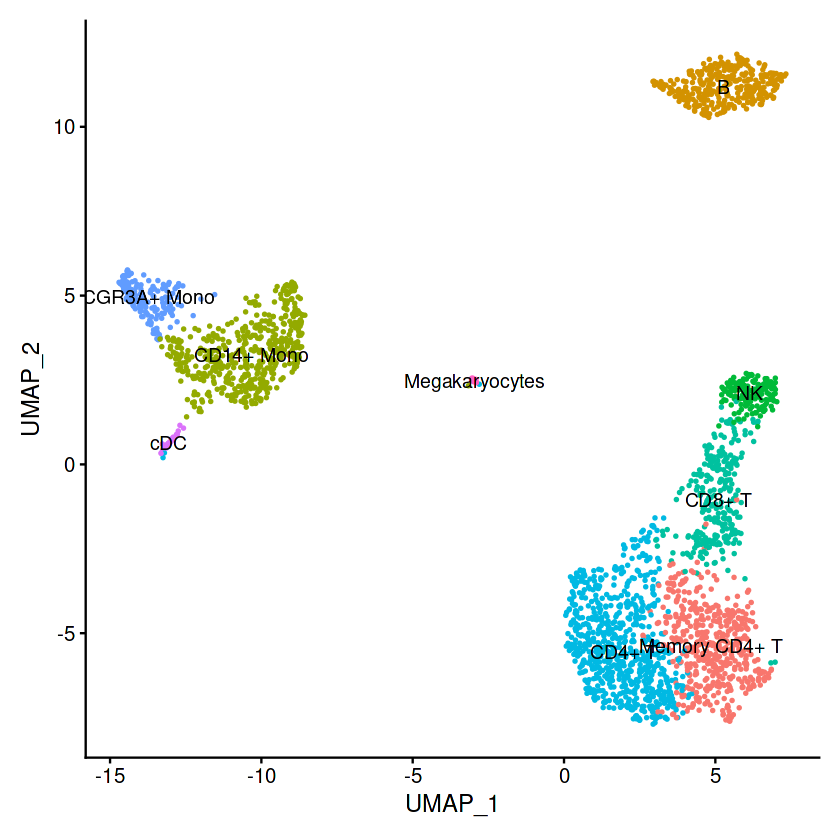

```r
pbmc$seurat_annotation <-  pbmc@active.ident
DimPlot(pbmc, reduction = "umap", label = TRUE, pt.size = 0.5) + NoLegend()
```

We intend to examine the Gene Regulatory Network (GRN) within the cell type data of the Myeloid lineage from the entire dataset.

```r
# Select subset of the interested dataset
pbmc_subset <- subset(pbmc, seurat_annotation=="CD14+ Mono"| seurat_annotation=="FCGR3A+ Mono" |
                   seurat_annotation == "cDC")
```

### 1-2. Converting seurat object to monocle2 object

```r
# convert Seurat Object to Monocle Object(CellDataSet)
cds_monocle_obj <- as.CellDataSet(pbmc_subset)
```

## 2. Constructing Single Cell Trajectories

Retrun to Index  
In monocle2, there are preliminary tasks required to compute pseudotime, and the method of ordering cells based on the expression of specific genes can also influence the resulting outcomes.

Size factors help us normalize for differences in mRNA recovered across cells, and "dispersion" values will help us perform differential expression analysis later

```r
# calculates size factors for the cells and estimates dispersions for the genes
cds_monocle_obj <- estimateSizeFactors(cds_monocle_obj)
cds_monocle_obj <- estimateDispersions(cds_monocle_obj)
```

```
Removing 198 outliers
```

```r
# load the modificated source code of Monocle2
source("../monocle_func1_ordercells.R")
source("../monocle_func2_methods_CellDataSet.R")
source("../monocle_func3_BEAM.R")
source("../monocle_func4_utils.R")
```

### 2-1. Choosing genes that define a cells's progress

Multiple strategies can be used to select genes for pseudotime estimation; the most common is to leverage **differentially expressed genes (DEGs)**. If DEG analysis has already been performed in **Seurat**, that gene set is appropriate for trajectory inference. Alternatively, **Monocle** provides native procedures to identify DEGs for this purpose.

To identify differentially expressed genes (DEGs) in **Seurat**, use the built-in DEG functions as illustrated below.

```r
head(pbmc_subset@meta.data)
```

A data.frame: 6 × 10

|  | orig.ident <fct> | nCount_RNA <dbl> | nFeature_RNA <int> | percent.mt <dbl> | log10GenesPerUMI <dbl> | RNA_snn_res.0.5 <fct> | RNA_snn_res.1 <fct> | RNA_snn_res.1.2 <fct> | seurat_clusters <fct> | seurat_annotation <fct> |
| --- | --- | --- | --- | --- | --- | --- | --- | --- | --- | --- |
| AAACCGTGCTTCCG-1 | pbmc3k_data | 2639 | 960 | 1.743085 | 0.8716423 | 1 | 4 | 4 | 4 | CD14+ Mono |
| AAACGCTGTTTCTG-1 | pbmc3k_data | 1103 | 550 | 2.901179 | 0.9006720 | 5 | 7 | 7 | 7 | FCGR3A+ Mono |
| AAAGAGACGCGAGA-1 | pbmc3k_data | 3033 | 1058 | 1.417738 | 0.8686377 | 1 | 4 | 4 | 4 | CD14+ Mono |
| AAAGCAGATATCGG-1 | pbmc3k_data | 4584 | 1422 | 1.396161 | 0.8611551 | 1 | 4 | 4 | 4 | CD14+ Mono |
| AAAGTTTGTAGCGT-1 | pbmc3k_data | 2683 | 877 | 2.497205 | 0.8583626 | 1 | 5 | 6 | 6 | CD14+ Mono |
| AAATCAACCCTATT-1 | pbmc3k_data | 5676 | 1541 | 2.431290 | 0.8491653 | 5 | 7 | 7 | 7 | FCGR3A+ Mono |

#### DEG analysis

If prior knowledge about the dataset has been curated in the Seurat object’s metadata, first inspect these fields and define explicit criteria for DEG identification. Relevant metadata may include differentiation state, experimental time point, or cell type.

In this tutorial, we used cell-type annotations recorded as `seurat_annotation` in `meta.data` (see Section 1-1, *Setting Up the Environment*) and performed DEG analysis with this annotation as the grouping variable.

```r
# seurat_annotation(cell type) is specified as "Idents" to use it for DEG analysis.
Idents(pbmc_subset) <- pbmc_subset$seurat_annotation
```

```r
# DEG analysis is performed, and the relevant information is stored in pbmc_subset.markers
DefaultAssay(pbmc_subset) <- "RNA"
all.genes <- rownames(pbmc_subset)
pbmc_subset <- ScaleData(pbmc_subset, verbose = FALSE, features = all.genes)
pbmc_subset.markers <- FindAllMarkers(pbmc_subset, only.pos = TRUE, min.pct = 0.25, logfc.threshold = 0.25)
head(pbmc_subset.markers)
```

A data.frame: 6 × 7

|  | p_val <dbl> | avg_log2FC <dbl> | pct.1 <dbl> | pct.2 <dbl> | p_val_adj <dbl> | cluster <fct> | gene <chr> |
| --- | --- | --- | --- | --- | --- | --- | --- |
| S100A8 | 9.016100e-75 | 3.855162 | 0.975 | 0.474 | 1.236468e-70 | CD14+ Mono | S100A8 |
| S100A9 | 1.528431e-73 | 3.320721 | 0.996 | 0.830 | 2.096091e-69 | CD14+ Mono | S100A9 |
| LYZ | 3.569685e-68 | 1.997125 | 1.000 | 0.985 | 4.895466e-64 | CD14+ Mono | LYZ |
| LGALS2 | 1.332293e-55 | 2.395330 | 0.908 | 0.356 | 1.827106e-51 | CD14+ Mono | LGALS2 |
| GPX1 | 1.642948e-39 | 1.387204 | 0.923 | 0.711 | 2.253139e-35 | CD14+ Mono | GPX1 |
| CD14 | 1.579085e-37 | 2.351563 | 0.667 | 0.165 | 2.165557e-33 | CD14+ Mono | CD14 |

> **NB** : The DEGs obtained here can be used to generate a Cell x Gene matrix for use as a Tenet input file.  
> This course continues from **4. Extracting the Cell x Gene matrix and Cell Select file**

```r
# Assign these genes for calculating the pseudotime later
sel.gene <- unique(pbmc_subset.markers$gene)
```

Breifly, we can obtain DEGs in Monocle as follows:  
After filtering genes expressed in various cells, we can use the differentialGeneTest function to identify differential expression genes.

```
cds_monocle_obj <- detectGenes(cds_monocle_obj, min_expr = 0.1)
expressed_genes <- row.names(subset(fData(cds_monocle_obj),
    num_cells_expressed >= 10))
diff_test_res <- differentialGeneTest(cds_monocle_obj[expressed_genes,],
               fullModelFormulaStr = "~annotation(cluster)")

sel.gene <- row.names (subset(diff_test_res, qval < 0.01))
```

```r
cds_monocle_obj <- monocle::setOrderingFilter(cds_monocle_obj, sel.gene)
```

### 2-2. Reducing data dimensionality

Dimensionality reduction is essential for visualizing and analyzing data, and thus, [**DDRTree**](http://cole-trapnell-lab.github.io/monocle-release/docs/#ddrtree-discriminative-dimensionality-reduction-via-learning-a-tree) has been utilized for this purpose.

```r
cds_monocle_obj <- monocle::reduceDimension(cds_monocle_obj, method = 'DDRTree')
```

### 2-3. Ordering cells along the trajectory

Pseudotime serves as an abstract measure of progress, quantifying the distance between a cell and the trajectory's starting point along the shortest route. The trajectory's overall length is defined by the total transcriptional changes a cell undergoes while transitioning from the initial state to the final state.  
The calculation of pseudotime is performed using the orderCells function, which can be time-consuming depending on the size of the data.  
( The current data will take 1~2 minute)

```r
cds_monocle_obj <- orderCells(cds_monocle_obj)
```

Following this, the plot_cell_trajectory function will be used to visualize the results.

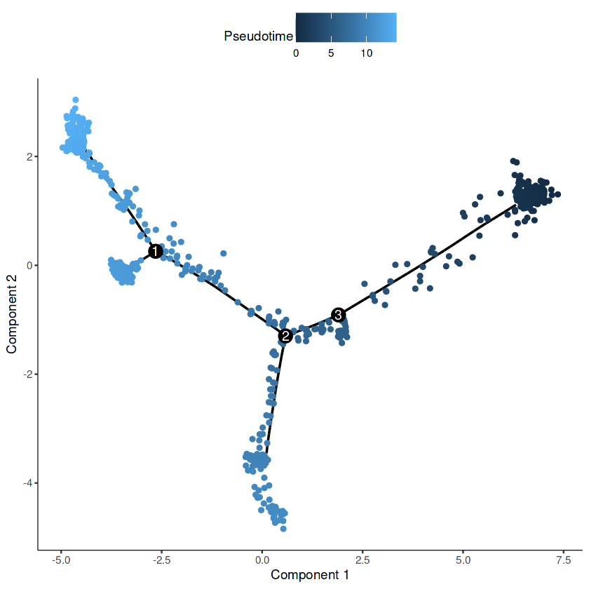

```r
# we can check Pseudotime along the cells
monocle::plot_cell_trajectory(cds_monocle_obj, color_by = "Pseudotime")
```

The results were also confirmed based on the annotation criteria.

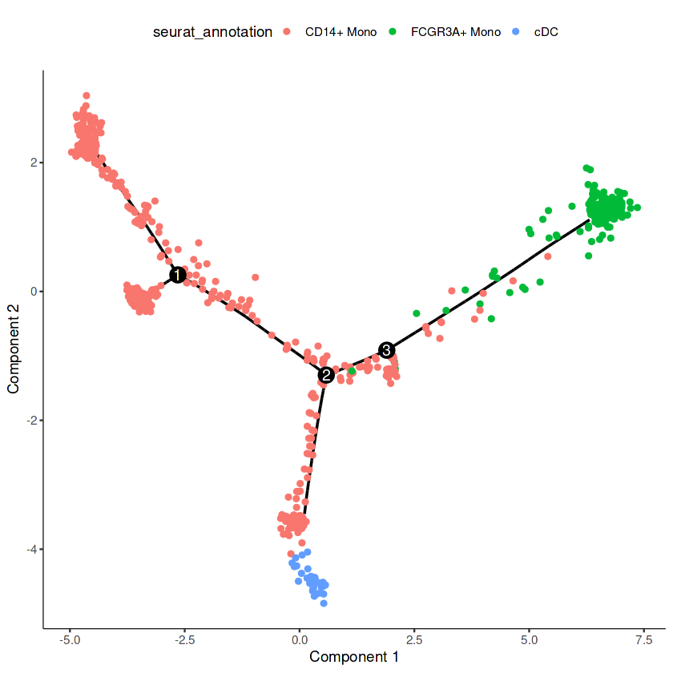

```r
# we can check seurat_annotation(celltype) on the pseudotime result
monocle::plot_cell_trajectory(cds_monocle_obj, color_by = "seurat_annotation")
```

"States" are defined based on branch points, separating clusters, and are considered to represent more similar biological processes than those not within the same state.

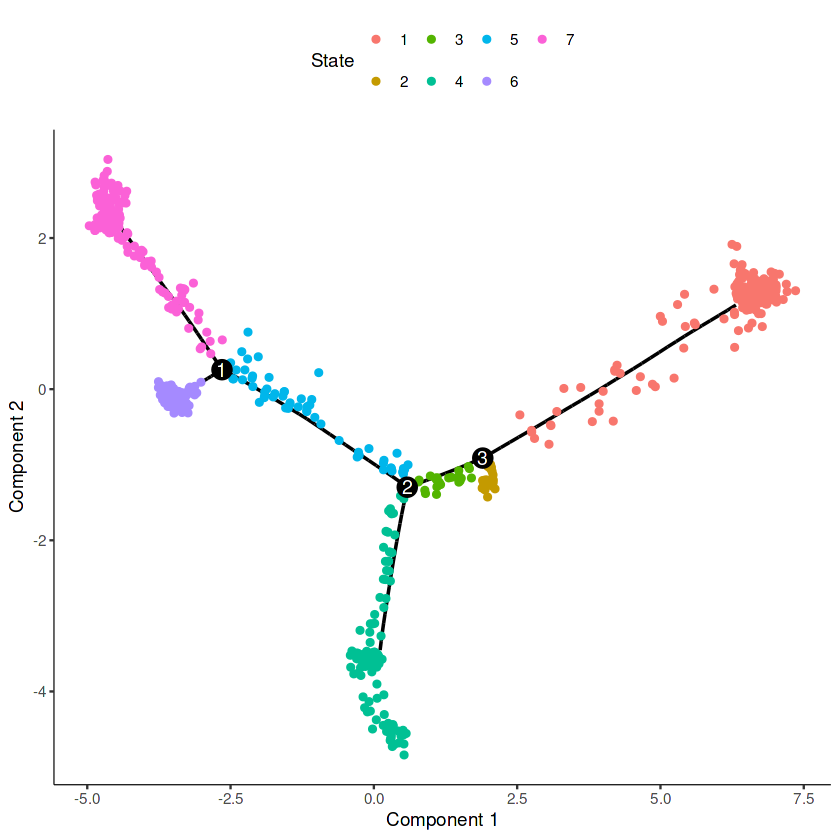

```r
# we can check state on the pseudotime result
monocle::plot_cell_trajectory(cds_monocle_obj, color_by = "State")
```

Based on biological knowledge such as differentiation, reprogramming, or an immune response, we can choose pseudotime starting point by root_state parameter. If you want to specify a start point, Please refer to the code just below.

```
cds_monocle_obj <- orderCells(cds_monocle_obj, root_state = another_state_point)
```

```r
cds_monocle_obj <- orderCells(cds_monocle_obj, root_state = 7)
```

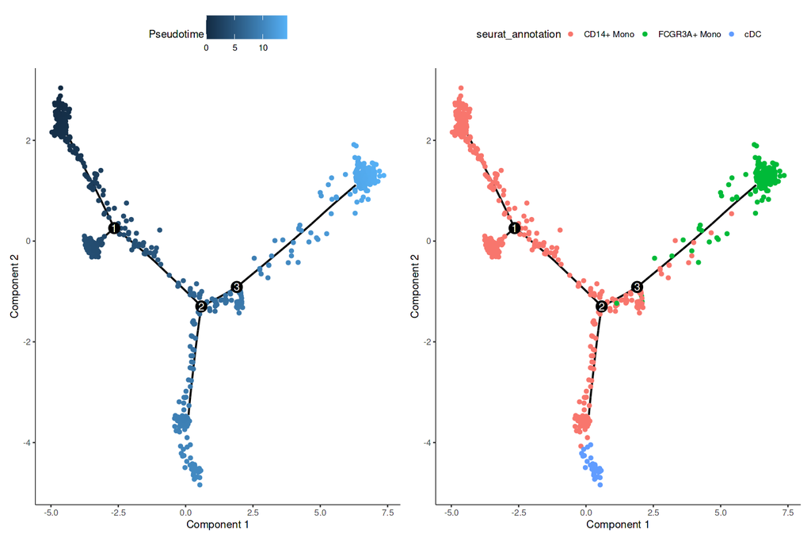

```r
# we can check Pseudotime along the cells
options(repr.plot.width=12, repr.plot.height=8)
monocle::plot_cell_trajectory(cds_monocle_obj, color_by = "Pseudotime")  | monocle::plot_cell_trajectory(cds_monocle_obj, color_by = "seurat_annotation")
```

## 3. Extracting the Pseudotime from a Monocle V2 object

Retrun to Index

To use as input for Tenet, it is necessary to store the Pseudotime information for each cell.

```r
# assign result of Pseudotime and Cell Barcodes in "pbmc_subset" to "pbmc_subset_result"
pbmc_subset_result <- cbind(colnames(cds_monocle_obj@assayData$exprs),cds_monocle_obj$Pseudotime)
colnames(pbmc_subset_result) <- c("Barcodes","Pseudotime")
```

If pseudotime was calculated without subsetting from the entire dataset, the following steps may not be necessary.

```r
pbmc_dataset <- as.data.frame(colnames(pbmc))
colnames(pbmc_dataset) <- "Barcodes"
pbmc_dataset <- merge(pbmc_dataset, pbmc_subset_result, by = "Barcodes", all.x = TRUE)
# Fill missing values in the pseudotime column with "Inf"
pbmc_dataset$Pseudotime[is.na(pbmc_dataset$Pseudotime)] <- Inf
# View resulting data frame
head(pbmc_dataset)
pbmc$pseudotime <- pbmc_dataset$Pseudotime
```

A data.frame: 6 × 2

|  | Barcodes <chr> | Pseudotime <chr> |
| --- | --- | --- |
| 1 | AAACATACAACCAC-1 | Inf |
| 2 | AAACATTGAGCTAC-1 | Inf |
| 3 | AAACATTGATCAGC-1 | Inf |
| 4 | AAACCGTGCTTCCG-1 | 7.48729367948213 |
| 5 | AAACCGTGTATGCG-1 | Inf |
| 6 | AAACGCACTGGTAC-1 | Inf |

## 4. Extracting the Cell x Gene matrix and Cell Select file

Retrun to Index  
TENET takes a lot of runtime with every gene and cell. To bulid the accurate Gene Regulatory Network (GRN) and reduce the resource consumption, TENET recommends subsetting the gene set using DEG or highly variable genes from specific cell types. But we have already identified the DEGs in **DEG analysis** part, so we can easily obtain the Cell X Gene matrix using these.

```r
# Make matrix using a DEG marker genes
pbmc_matrix <- as.data.frame(as.matrix(t(pbmc@assays[["RNA"]]@counts[unique(pbmc_subset.markers$gene),])))
pbmc_matrix <- cbind(as.data.frame(rownames(pbmc_matrix)),pbmc_matrix)
colnames(pbmc_matrix)[1] <- "TENET"
dim(pbmc_matrix)
```

1. 2638

2. 1009

```r
# select specific cells
pbmc_cell_select <- data.frame(annotation=(as.character(pbmc$seurat_annotation)))
select_cell_types <- c("CD14+ Mono","FCGR3A+ Mono","DC")
# Create new column with 1 if annotation matches annotation_info, 0 otherwise
pbmc_cell_select$match <- ifelse(pbmc_cell_select$annotation %in% select_cell_types, 1, 0)

# View resulting data frame
tail(pbmc_cell_select)

pbmc$cell_select <- pbmc_cell_select$match
```

A data.frame: 6 × 2

|  | annotation <chr> | match <dbl> |
| --- | --- | --- |
| 2633 | cDC | 0 |
| 2634 | CD14+ Mono | 1 |
| 2635 | B | 0 |
| 2636 | B | 0 |
| 2637 | B | 0 |
| 2638 | CD4+ T | 0 |